# Лабораторная работа №5

Построение графиков

Умед Джамшедович Назармамадов

Российский университет дружбы народов

2026-11-07

# Информация

## Докладчик

- Назармамадов Умед Джамшедович
- Студент группы НФИбд-02-23
- Факультет физико-математических и естественных наук
- Российский университет дружбы народов

# Вводная часть

## Актуальность

- Графики помогают исследовать поведение функций
- Визуализация позволяет сравнивать данные и замечать закономерности
- Julia поддерживает двумерные и трёхмерные графики, а также анимации

## Объект и предмет исследования

- Объект: средства визуализации данных в Julia
- Предмет:
  - построение и оформление графиков
  - отображение случайных данных и погрешностей
  - создание подграфиков и анимаций

## Цель и задачи

**Цель:** освоить синтаксис языка Julia для построения графиков.

**Задачи:**

- Повторить примеры методических указаний
- Настроить подписи осей, легенды и оформление
- Выполнить самостоятельные задания
- Создать анимации функций и кривых

## Материалы и методы

- WSL Ubuntu
- Julia и JupyterLab с ядром IJulia
- Пакеты: `Plots`, `PyPlot`, `UnicodePlots`
- Обработка данных: `Statistics`, `Distributions`
- Фиксация результатов: скриншоты и сохранённые изображения

# Ход работы

## Основные команды построения

| Команда | Назначение |
| --- | --- |
| `plot()` | Создание графика |
| `plot!()` | Добавление к существующему графику |
| `scatter()` | Точечный график |
| `surface()` | Поверхность |
| `contour()` | Линии уровня |
| `savefig()` | Сохранение рисунка |

## Графические механизмы

- GR: обычные графики
- PyPlot: использован для большинства построений
- Plotly: интерактивное представление
- UnicodePlots: график из текстовых символов

## Синус и ряд Тейлора

$$\sin(x)\approx
x-\frac{x^3}{3!}+\frac{x^5}{5!}
-\frac{x^7}{7!}+\frac{x^9}{9!}$$

- Около нуля кривые практически совпадают
- При удалении от нуля отличие увеличивается
- Настроены стили линий, заливка, фон и отметки осей

## Точечные графики и распределения

- Двумерные и трёхмерные случайные точки
- Размер и прозрачность маркеров
- Гистограммы случайных возрастов
- Нормальное распределение: среднее 35, стандартное отклонение 10

## Приближение данных полиномом

- Исходные данные: экспонента со случайными отклонениями
- Приближение: полином пятой степени
- Коэффициенты: `c = A \ y`

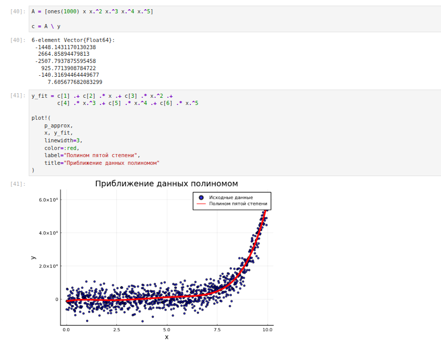

Приближение данных полиномом

## Полярные и параметрические графики

**Полярный график:**

$$r(\theta)=1+\cos(\theta)\sin^2(\theta)$$

**Кривая на плоскости:**

$$x(t)=\sin(t),\qquad y(t)=\sin(2t)$$

**Кривая в пространстве:**

$$x(t)=\cos(t),\quad y(t)=\sin(t),\quad z(t)=\sin(5t)$$

## Поверхности и линии уровня

- Поверхность: высота зависит от двух координат
- Каркас: поверхность изображается сеткой линий
- Мелкий шаг сетки делает изображение более гладким
- Линии уровня соединяют точки одинаковой высоты

## Градиентное поле

$$h(x,y)=x^3-3x+y^2,
\qquad
\nabla h=(3x^2-3,\;2y)$$

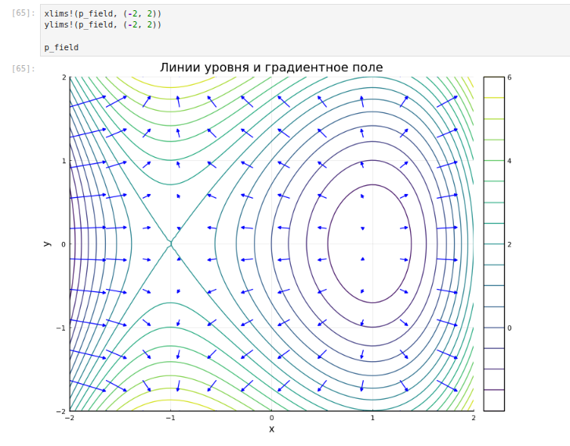

Линии уровня и градиентное поле

## Две вертикальные шкалы

$$y_1=\pi x,\qquad y_2=e^x\cos(x)$$

- При общей шкале изменение первой функции плохо заметно
- `twinx()` добавляет отдельную правую ось

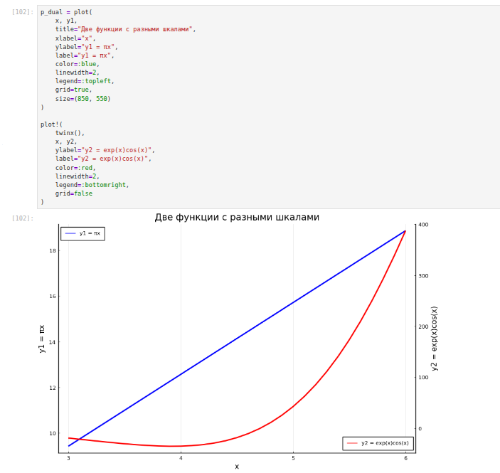

Функции с разными шкалами

## Погрешности и подграфики

**Неопределённость значений:**

- `yerror`, `xerror`: вертикальные и горизонтальные отрезки
- `ribbon`: цветная полоса вокруг линии

**Расположение графиков:**

- `layout=(2,2)`: сетка из четырёх графиков
- `grid`: настройка долей высоты
- `@layout`: сложные макеты

## Анимация синусоиды

- Подготовлены 120 точек на отрезке от 0 до $2\pi$
- Каждый кадр добавляет следующую точку
- Красный маркер показывает конец кривой
- Масштаб осей остаётся постоянным

## Гипоциклоиды и эпициклоиды

| Кривая | Движение маленькой окружности |
| --- | --- |
| Гипоциклоида | Внутри большой окружности |
| Эпициклоида | Снаружи большой окружности |

- Отношение радиусов: $k=R/r$
- Гипоциклоиды: $k=3,\;4,\;5/2,\;7/2$
- На скриншотах эпициклоид представлены $k=3,\;4$

## Влияние отношения радиусов

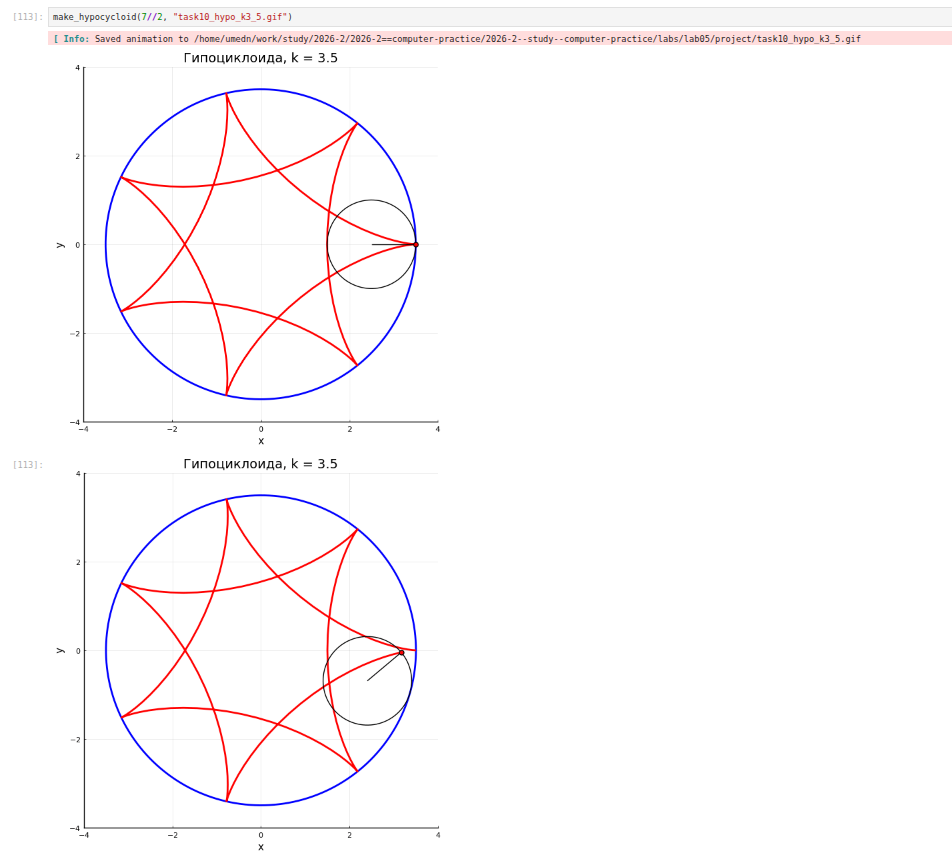

Гипоциклоида при k = 7/2

# Результаты

## Что получено

- Построены графики функций и случайных данных
- Настроены подписи, легенды, цвета и стили
- Рассмотрены поверхности, линии уровня и векторные поля
- Реализованы макеты подграфиков и формирование анимаций
- Подтверждено сохранение четырёх гипоциклоид и двух эпициклоид

## Ограничения и доработка

- PyPlot не поддержал стиль `:dashdotdot`
- Plotly не показал график непосредственно в ноутбуке
- Пример с шестью типами подграфиков требует исправления
- Нужно добавить результаты эпициклоид при $k=5/2$ и $k=7/2$

# Заключение

## Главный вывод

Средства Julia позволяют наглядно представлять функции и данные.

Выбор типа графика, масштаба и оформления влияет на то, насколько легко понять результат.